# Final Project MGMT411 - Larry Fink

## Apple Stock Analysis

##### Analysis by Teammates: Nicole Carney, Eli Devlin, Andrew George, and Kirstyn Yoder

##### Code By: Martin Dieck Iza

### What do we need to analyze Apple's stock?

1. Several databases have been provided to help in this analysis:
   - **Financial Ratios:** includes over 70 financial ratios based on quarterly financial statements.
   - **Technical Indicators:** includes several popular trend indicators and cumulative return data points for analysis.
   - **Risk Measures:** includes some of the most important risk measures such as volatility and beta.
   - **Investor Data:** includes ownership and trading activity of different investors.
1. Additionally, a database containing 400 of the most common investment trading signals or "factors" and their historic monthly values has been attached as well. This will function as a basis for additional data points to use when deciding to invest or not in Apple stock. These signals are classified into 13 categories and have each been backed up by academic research.

###### Step 1: Prepare Python Libraries and Directories

```python
import numpy as np # This is for numerical analysis
import pandas as pd # This introduces the DataFrame object

import statsmodels.api as sm # This is for regression analysis
import matplotlib.pyplot as plt # This is for plotting results
%matplotlib inline
# For displaying code inline to plots

from pandas.tseries.offsets import *
from dateutil.relativedelta import *

from operator import itemgetter # To sort dictionary values
import matplotlib.ticker as mtick # For plotting formatting
from itertools import combinations # For iteration and regression analysis

import os
```

**Clean and prepare the Jupyter Workspace**

```python
from IPython.core.pylabtools import figsize
from IPython.core.interactiveshell import InteractiveShell
InteractiveShell.ast_node_interactivity = "all" # Make Jupyter Notebook print all results including intermediate
pd.options.display.float_format = '{:,.3f}'.format # Make Pandas dataframes display 3 decimal floats
pd.set_option('use_inf_as_na', True) # Treat INF same as NA or NAN
pd.set_option('display.max_columns', 500) # Display a max of 500 columns
pd.set_option('display.max_rows', 500) # Display a max of 500 rows
idx = pd.IndexSlice # Prepares dataframe indexing for more intuitive command
import warnings
warnings.filterwarnings('ignore') # Never print matching warnings
```

**Prepare file directories**

```python
# Change the directory here for desired path location
Project = r'/Users/martin/Documents/Purdue/Investment Management/Letter of Recommendation Documents - Martin Dieck/Final Project/'
FigProj = r'/Users/martin/Documents/Purdue/Investment Management/Letter of Recommendation Documents - Martin Dieck/Final Project/Figures/'
```

## Financial Ratios

### Import the dataset of financial ratios

Important ratios for further analysis:

- **EOM:** End of month
- **Return:** Monthly holding-period return.
- **Shillers Cyclically Adjusted P/E Ratio:** Price earnings ratio based on average inflation-adjusted earnings from the previous 10 years *(lower = better)*.
- **Book/Market:** compares a firm's book value to its market value *(higher = cheaper)*.
- **Return on Assets:** indicates how profitable a company is in relation to its total assets *(higher = better)*.
- **Return on Equity:** indicates how profitable a company is in relation to its total equity *(higher = better)*.
- **Gross Profit/Total Assets (GPA):** used to determine how efficiently a firm uses its assets to generate Gross Profits *(higher = better)*.
- **Total Debt/Equity:** used to evaluate a company's financial leverage *(lower = less debt)*.
- **Interest Coverage Ratio:** used to determine how easily a company can pay interest on its outstanding debt. *(higher = better)*
- **Inventory Turnover:** shows how many times a company turned over its inventory relative to its COGS in a given period *(higher = more turnover)*.
- **Receivables Turnover:** measures the number of times a company collects its average accounts receivable balance *(higher = more turnover)*.
- **Payables Turnover:** used to quantify the rate at which a company pays off its suppliers *(higher = more turnover)*.

```python
fr = pd.read_csv(Project+'Financial Ratios.csv', parse_dates = ['EOM'])
fr.tail()
```

|  | EOM | Return | Shillers Cyclically Adjusted P/E Ratio | Book/Market | Enterprise Value Multiple | Price/Operating Earnings (Basic, Excl. EI) | Price/Operating Earnings (Diluted, Excl. EI) | P/E (Diluted, Excl. EI) | P/E (Diluted, Incl. EI) | Price/Sales | Price/Cash flow | Dividend Payout Ratio | Net Profit Margin | Operating Profit Margin Before Depreciation | Operating Profit Margin After Depreciation | Gross Profit Margin | Pre-tax Profit Margin | Cash Flow Margin | Return on Assets | Return on Equity | Return on Capital Employed | Effective Tax Rate | After-tax Return on Average Common Equity | After-tax Return on Invested Capital | After-tax Return on Total Stockholders Equity | Pre-tax return on Net Operating Assets | Pre-tax Return on Total Earning Assets | Gross Profit/Total Assets | Common Equity/Invested Capital | … |
| --- | --- | --- | --- | --- | --- | --- | --- | --- | --- | --- | --- | --- | --- | --- | --- | --- | --- | --- | --- | --- | --- | --- | --- | --- | --- | --- | --- | --- | --- | --- |
| 250 | 2020-11-30 | 0.095 | 35.010 | 0.050 | 17.190 | 8.180 | 8.250 | 8.250 | 8.250 | 6.760 | 23.130 | 0.240 | 0.210 | 0.290 | 0.250 | 0.420 | 0.250 | 0.260 | 0.240 | 0.650 | 0.330 | 0.160 | 0.660 | 0.330 | 0.660 | 0.720 | 0.350 | 0.350 | 0.460 | … |
| 251 | 2020-12-31 | 0.115 | 38.010 | 0.030 | 27.000 | 35.970 | 36.300 | 36.300 | 36.300 | 7.370 | 25.090 | 0.250 | 0.210 | 0.280 | 0.240 | 0.420 | 0.240 | 0.250 | 0.230 | 0.700 | 0.340 | 0.140 | 0.740 | 0.320 | 0.740 | 0.740 | 0.340 | 0.360 | 0.380 | … |
| 252 | 2021-01-31 | -0.006 | 42.370 | 0.030 | 27.000 | 40.090 | 40.450 | 40.450 | 40.450 | 8.220 | 27.960 | 0.250 | 0.210 | 0.280 | 0.240 | 0.420 | 0.240 | 0.250 | 0.230 | 0.700 | 0.340 | 0.140 | 0.740 | 0.320 | 0.740 | 0.740 | 0.340 | 0.360 | 0.380 | … |
| 253 | 2021-02-28 | -0.080 | 41.690 | 0.030 | 27.000 | 39.870 | 40.230 | 40.230 | 40.230 | 8.090 | 27.520 | 0.250 | 0.210 | 0.280 | 0.240 | 0.420 | 0.240 | 0.250 | 0.230 | 0.700 | 0.340 | 0.140 | 0.740 | 0.320 | 0.740 | 0.740 | 0.340 | 0.360 | 0.380 | … |
| 254 | 2021-03-31 | 0.007 | 38.070 | 0.030 | 21.540 | 32.440 | 32.840 | 32.840 | 32.840 | 6.940 | 22.940 | 0.220 | 0.220 | 0.290 | 0.250 | 0.420 | 0.250 | 0.250 | 0.260 | 0.830 | 0.380 | 0.140 | 0.840 | 0.370 | 0.840 | 0.800 | 0.390 | 0.380 | 0.410 | … |

**Describing the selected variables.**

```python
fr[['Return','Shillers Cyclically Adjusted P/E Ratio','Book/Market','Return on Assets','Return on Equity','Gross Profit/Total Assets','Total Debt/Equity','Interest Coverage Ratio','Inventory Turnover','Receivables Turnover','Payables Turnover']].describe()
```

|  | Return | Shillers Cyclically Adjusted P/E Ratio | Book/Market | Return on Assets | Return on Equity | Gross Profit/Total Assets | Total Debt/Equity | Interest Coverage Ratio | Inventory Turnover | Receivables Turnover | Payables Turnover |
| --- | --- | --- | --- | --- | --- | --- | --- | --- | --- | --- | --- |
| count | 255.000 | 255.000 | 255.000 | 255.000 | 255.000 | 255.000 | 255.000 | 162.000 | 255.000 | 255.000 | 255.000 |
| mean | 0.027 | 30.746 | 0.282 | 0.213 | 0.277 | 0.347 | 0.991 | 78.986 | 87.104 | 8.964 | 4.504 |
| std | 0.116 | 94.511 | 0.185 | 0.118 | 0.159 | 0.060 | 0.715 | 160.627 | 77.728 | 1.253 | 0.687 |
| min | -0.577 | -619.660 | 0.030 | -0.040 | -0.010 | 0.220 | 0.480 | -20.810 | 25.700 | 5.490 | 2.900 |
| 25% | -0.035 | 18.840 | 0.165 | 0.120 | 0.210 | 0.300 | 0.560 | 13.050 | 51.540 | 8.050 | 4.060 |
| 50% | 0.033 | 28.120 | 0.220 | 0.220 | 0.290 | 0.350 | 0.660 | 25.140 | 57.820 | 9.080 | 4.590 |
| 75% | 0.098 | 54.970 | 0.310 | 0.290 | 0.350 | 0.390 | 1.165 | 97.180 | 81.900 | 10.000 | 4.960 |
| max | 0.454 | 222.480 | 0.840 | 0.470 | 0.830 | 0.510 | 3.960 | 941.750 | 422.480 | 11.800 | 6.060 |

**Finding the correlation between these variables.**

```python
fr[['Return','Shillers Cyclically Adjusted P/E Ratio','Book/Market','Return on Assets','Return on Equity','Gross Profit/Total Assets','Total Debt/Equity','Interest Coverage Ratio','Inventory Turnover','Receivables Turnover','Payables Turnover']].corr()
```

|  | Return | Shillers Cyclically Adjusted P/E Ratio | Book/Market | Return on Assets | Return on Equity | Gross Profit/Total Assets | Total Debt/Equity | Interest Coverage Ratio | Inventory Turnover | Receivables Turnover | Payables Turnover |
| --- | --- | --- | --- | --- | --- | --- | --- | --- | --- | --- | --- |
| Return | 1.000 | 0.128 | 0.024 | -0.026 | -0.017 | 0.014 | 0.002 | -0.012 | -0.176 | 0.032 | 0.056 |
| Shillers Cyclically Adjusted P/E Ratio | 0.128 | 1.000 | -0.259 | 0.199 | 0.055 | 0.300 | -0.054 | 0.178 | -0.547 | 0.211 | 0.002 |
| Book/Market | 0.024 | -0.259 | 1.000 | -0.649 | -0.777 | -0.515 | -0.457 | -0.110 | 0.492 | 0.280 | 0.270 |
| Return on Assets | -0.026 | 0.199 | -0.649 | 1.000 | 0.736 | 0.807 | 0.076 | 0.343 | -0.511 | 0.143 | -0.146 |
| Return on Equity | -0.017 | 0.055 | -0.777 | 0.736 | 1.000 | 0.485 | 0.688 | 0.001 | -0.470 | -0.325 | -0.451 |
| Gross Profit/Total Assets | 0.014 | 0.300 | -0.515 | 0.807 | 0.485 | 1.000 | -0.209 | 0.442 | -0.318 | 0.413 | 0.301 |
| Total Debt/Equity | 0.002 | -0.054 | -0.457 | 0.076 | 0.688 | -0.209 | 1.000 | -0.219 | -0.312 | -0.647 | -0.686 |
| Interest Coverage Ratio | -0.012 | 0.178 | -0.110 | 0.343 | 0.001 | 0.442 | -0.219 | 1.000 | -0.166 | 0.287 | 0.258 |
| Inventory Turnover | -0.176 | -0.547 | 0.492 | -0.511 | -0.470 | -0.318 | -0.312 | -0.166 | 1.000 | 0.094 | 0.390 |
| Receivables Turnover | 0.032 | 0.211 | 0.280 | 0.143 | -0.325 | 0.413 | -0.647 | 0.287 | 0.094 | 1.000 | 0.716 |
| Payables Turnover | 0.056 | 0.002 | 0.270 | -0.146 | -0.451 | 0.301 | -0.686 | 0.258 | 0.390 | 0.716 | 1.000 |

It is interesting to note that, out of these selected ratios, Inventory Turnover has the highest absolute value of the correlation. This means that it is the most likely to follow a pattern with the return, although, in this case, it would be an inverse pattern because of its negative sign.

**Creating preliminary Return plot**

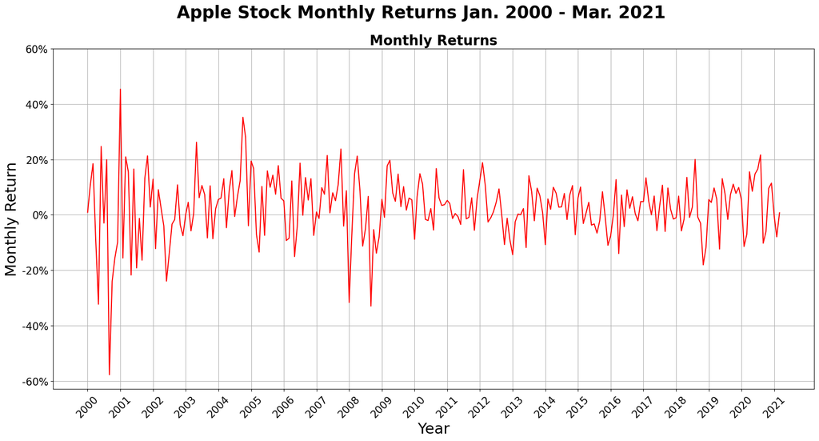

```python
fig, ax = plt.subplots(1, 1, figsize = (20,9))
fig.suptitle('Apple Stock Monthly Returns Jan. 2000 - Mar. 2021', fontsize = 25, fontweight = 'bold')

plt.title('Monthly Returns', fontsize = 20, fontweight = 'bold')
plt.plot(fr['EOM'],fr['Return'],'r')
plt.ylabel('Monthly Return', fontsize = 22)
plt.xlabel('Year', fontsize = 22)
plt.yticks([-0.6,-0.4,-0.2,0,0.2,0.4,0.6], ['-60%','-40%','-20%','0%','20%','40%','60%'], fontsize = 15)
plt.xticks(rotation = 45, fontsize = 15)
plt.xticks(['2000-01-31','2001-01-31','2002-01-31','2003-01-31','2004-01-31','2005-01-31','2006-01-31','2007-01-31','2008-01-31','2009-01-31','2010-01-31','2011-01-31','2012-01-31','2013-01-31','2014-01-31','2015-01-31','2016-01-31','2017-01-31','2018-01-31','2019-01-31','2020-01-31','2021-01-31'],['2000','2001','2002','2003','2004','2005','2006','2007','2008','2009','2010','2011','2012','2013','2014','2015','2016','2017','2018','2019','2020','2021'])
plt.grid()

plt.show();
```

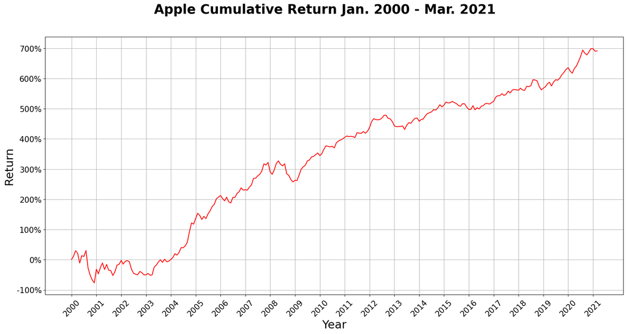

```python
fig, ax = plt.subplots(1, 1, figsize = (20,9))
fig.suptitle('Apple Cumulative Return Jan. 2000 - Mar. 2021', fontsize = 25, fontweight = 'bold')
ax.plot(fr['EOM'],fr['Return'].cumsum(),'r')
plt.ylabel('Return', fontsize = 22)
plt.xlabel('Year', fontsize = 22)
plt.yticks([-1,0,1,2,3,4,5,6,7], ['-100%','0%','100%','200%','300%','400%','500%','600%','700%'], fontsize = 15)
plt.xticks(rotation = 45, fontsize = 15)
plt.xticks(['2000-01-31','2001-01-31','2002-01-31','2003-01-31','2004-01-31','2005-01-31','2006-01-31','2007-01-31','2008-01-31','2009-01-31','2010-01-31','2011-01-31','2012-01-31','2013-01-31','2014-01-31','2015-01-31','2016-01-31','2017-01-31','2018-01-31','2019-01-31','2020-01-31','2021-01-31'],['2000','2001','2002','2003','2004','2005','2006','2007','2008','2009','2010','2011','2012','2013','2014','2015','2016','2017','2018','2019','2020','2021'])
plt.grid()
plt.show();
```

**Joining both graphs and saving figure**

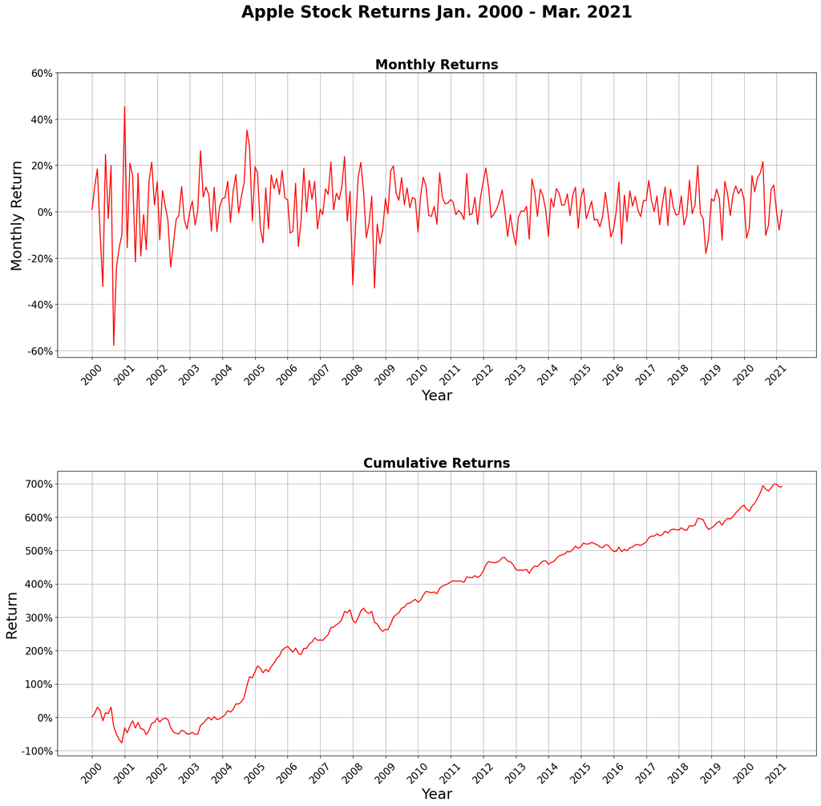

```python
fig, (ax1, ax2) = plt.subplots(2, 1, figsize = (20,18))
plt.subplots_adjust(left=0.1, bottom=0.1, right=0.9, top=0.9, wspace=0.4, hspace=0.4)
fig.suptitle('Apple Stock Returns Jan. 2000 - Mar. 2021', fontsize = 25, fontweight = 'bold')

ax1.set_title('Monthly Returns', fontsize = 20, fontweight = 'bold')
ax1.plot(fr['EOM'],fr['Return'],'r')
ax1.set_ylabel('Monthly Return', fontsize = 22)
ax1.set_xlabel('Year', fontsize = 22)
ax1.set_yticks([-0.6,-0.4,-0.2,0,0.2,0.4,0.6], ['-60%','-40%','-20%','0%','20%','40%','60%'], fontsize = 15)
ax1.set_xticks(['2000-01-31','2001-01-31','2002-01-31','2003-01-31','2004-01-31','2005-01-31','2006-01-31','2007-01-31','2008-01-31','2009-01-31','2010-01-31','2011-01-31','2012-01-31','2013-01-31','2014-01-31','2015-01-31','2016-01-31','2017-01-31','2018-01-31','2019-01-31','2020-01-31','2021-01-31'],['2000','2001','2002','2003','2004','2005','2006','2007','2008','2009','2010','2011','2012','2013','2014','2015','2016','2017','2018','2019','2020','2021'],rotation = 45, fontsize = 15)
ax1.grid()

ax2.set_title('Cumulative Returns', fontsize = 20, fontweight = 'bold')
ax2.plot(fr['EOM'],fr['Return'].cumsum(),'r')
ax2.set_ylabel('Return', fontsize = 22)
ax2.set_xlabel('Year', fontsize = 22)
ax2.set_yticks([-1,0,1,2,3,4,5,6,7], ['-100%','0%','100%','200%','300%','400%','500%','600%','700%'], fontsize = 15)
ax2.set_xticks(['2000-01-31','2001-01-31','2002-01-31','2003-01-31','2004-01-31','2005-01-31','2006-01-31','2007-01-31','2008-01-31','2009-01-31','2010-01-31','2011-01-31','2012-01-31','2013-01-31','2014-01-31','2015-01-31','2016-01-31','2017-01-31','2018-01-31','2019-01-31','2020-01-31','2021-01-31'],['2000','2001','2002','2003','2004','2005','2006','2007','2008','2009','2010','2011','2012','2013','2014','2015','2016','2017','2018','2019','2020','2021'],rotation = 45, fontsize = 15)
ax2.grid()

plt.show();

fig.savefig(FigProj+"Apple_Month&Cum_Returns.png", bbox_inches = 'tight');
```

**Creating preliminary Inventory Turnover plot**

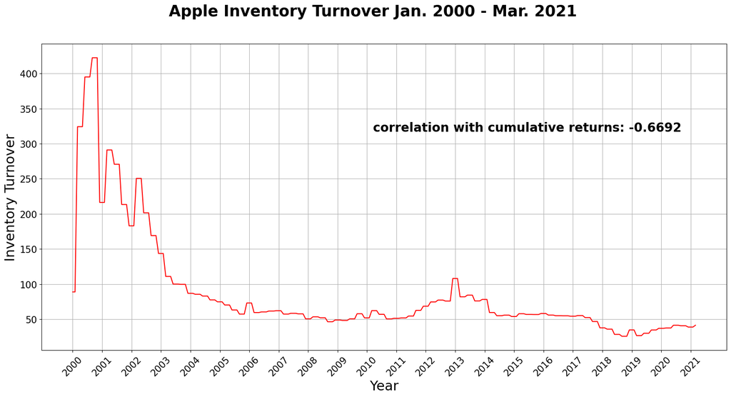

```python
ret_cumsum = fr['Return'].cumsum()
ret_cor = ret_cumsum.corr(fr['Inventory Turnover'])

fig, ax = plt.subplots(1, 1, figsize = (20,9))
fig.suptitle('Apple Inventory Turnover Jan. 2000 - Mar. 2021', fontsize = 25, fontweight = 'bold')
ax.plot(fr['EOM'],fr['Inventory Turnover'],'r')
plt.ylabel('Inventory Turnover', fontsize = 22)
plt.xlabel('Year', fontsize = 22)
plt.yticks(fontsize = 15)
plt.xticks(rotation = 45, fontsize = 15)
plt.xticks(['2000-01-31','2001-01-31','2002-01-31','2003-01-31','2004-01-31','2005-01-31','2006-01-31','2007-01-31','2008-01-31','2009-01-31','2010-01-31','2011-01-31','2012-01-31','2013-01-31','2014-01-31','2015-01-31','2016-01-31','2017-01-31','2018-01-31','2019-01-31','2020-01-31','2021-01-31'],['2000','2001','2002','2003','2004','2005','2006','2007','2008','2009','2010','2011','2012','2013','2014','2015','2016','2017','2018','2019','2020','2021'])
plt.grid()
plt.figtext(0.5,0.66,'correlation with cumulative returns: '+str(round(ret_cor,4)), fontsize=20, fontweight = 'bold')
plt.show();
fig.savefig(FigProj+"Apple_InventoryTurnover.png", bbox_inches = 'tight');
```

## Technical Indicators

### Import the dataset of technical indicators

**Indicator Key:**

- At the end of month *t*, *ret_i_j* indicates the cumulative return over the period *t-j* to *t-i*. For example, *ret_6_0* at *2001-12-31* is the cumulative return over *2001-07-31 to 2001-12-31*.

```python
ti_up = pd.read_csv(Project+'Technical Indicators.csv')
ti = pd.read_csv((Project+'Technical Indicators.csv'), parse_dates = ['EOM'])
ti_up.head()
```

|  | EOM | Return | ret_1_0 | ret_2_0 | ret_3_0 | ret_3_1 | ret_6_0 | ret_6_1 | ret_9_0 | ret_9_1 | ret_12_0 | ret_12_1 | ret_12_7 | ret_18_1 | ret_24_1 | ret_24_12 | ret_36_1 | ret_36_12 | ret_48_12 | ret_48_1 | ret_60_1 | ret_60_12 | ret_60_36 |
| --- | --- | --- | --- | --- | --- | --- | --- | --- | --- | --- | --- | --- | --- | --- | --- | --- | --- | --- | --- | --- | --- | --- | --- |
| 0 | 29-Feb-00 | 0.105 | 0.009 | 0.060 | 0.295 | 0.283 | 0.863 | 0.846 | 1.255 | 1.235 | 1.519 | 1.496 | 0.124 | 1.969 | 4.614 | 1.249 | 5.184 | 1.477 | 0.491 | 2.722 | 1.577 | 0.032 | -0.583 |
| 1 | 31-Mar-00 | 0.185 | 0.105 | 0.115 | 0.171 | 0.060 | 0.757 | 0.590 | 1.601 | 1.355 | 2.293 | 1.980 | 0.600 | 2.327 | 3.392 | 0.474 | 5.385 | 1.142 | 0.266 | 2.773 | 1.650 | -0.111 | -0.585 |
| 2 | 30-Apr-00 | -0.087 | 0.185 | 0.309 | 0.321 | 0.115 | 1.145 | 0.810 | 1.933 | 1.475 | 2.779 | 2.190 | 0.816 | 2.007 | 3.168 | 0.307 | 5.281 | 0.969 | 0.463 | 3.667 | 2.281 | 0.029 | -0.478 |
| 3 | 31-May-00 | -0.323 | -0.087 | 0.082 | 0.196 | 0.309 | 0.548 | 0.695 | 1.228 | 1.439 | 1.697 | 1.952 | 0.376 | 2.658 | 3.961 | 0.680 | 6.989 | 1.706 | 0.887 | 4.572 | 2.582 | 0.213 | -0.552 |
| 4 | 30-Jun-00 | 0.247 | -0.323 | -0.382 | -0.267 | 0.082 | -0.142 | 0.268 | 0.287 | 0.901 | 0.906 | 1.816 | 0.818 | 2.885 | 3.660 | 0.655 | 6.462 | 1.650 | 0.687 | 3.749 | 2.003 | 0.066 | -0.598 |

```python
ti.describe()
```

|  | Return | ret_1_0 | ret_2_0 | ret_3_0 | ret_3_1 | ret_6_0 | ret_6_1 | ret_9_0 | ret_9_1 | ret_12_0 | ret_12_1 | ret_12_7 | ret_18_1 | ret_24_1 | ret_24_12 | ret_36_1 | ret_36_12 | ret_48_12 | ret_48_1 | ret_60_1 | ret_60_12 | ret_60_36 |
| --- | --- | --- | --- | --- | --- | --- | --- | --- | --- | --- | --- | --- | --- | --- | --- | --- | --- | --- | --- | --- | --- | --- |
| count | 261.000 | 261.000 | 261.000 | 261.000 | 261.000 | 261.000 | 261.000 | 261.000 | 261.000 | 261.000 | 261.000 | 261.000 | 261.000 | 261.000 | 261.000 | 261.000 | 261.000 | 261.000 | 261.000 | 261.000 | 261.000 | 261.000 |
| mean | 0.027 | 0.027 | 0.056 | 0.087 | 0.057 | 0.189 | 0.156 | 0.302 | 0.267 | 0.431 | 0.393 | 0.168 | 0.667 | 0.986 | 0.445 | 1.784 | 1.070 | 1.837 | 2.719 | 3.669 | 2.689 | 0.998 |
| std | 0.115 | 0.115 | 0.169 | 0.217 | 0.169 | 0.347 | 0.307 | 0.470 | 0.429 | 0.605 | 0.563 | 0.318 | 0.856 | 1.227 | 0.619 | 2.056 | 1.348 | 2.158 | 3.154 | 4.353 | 3.284 | 1.394 |
| min | -0.577 | -0.577 | -0.679 | -0.729 | -0.679 | -0.716 | -0.707 | -0.781 | -0.760 | -0.711 | -0.731 | -0.707 | -0.750 | -0.750 | -0.711 | -0.779 | -0.758 | -0.792 | -0.648 | -0.033 | -0.602 | -0.758 |
| 25% | -0.035 | -0.035 | -0.036 | -0.026 | -0.036 | 0.006 | -0.011 | 0.018 | 0.009 | 0.009 | 0.013 | -0.008 | 0.036 | 0.114 | 0.009 | 0.575 | 0.152 | 0.585 | 1.007 | 1.054 | 0.837 | 0.097 |
| 50% | 0.037 | 0.034 | 0.060 | 0.089 | 0.060 | 0.174 | 0.139 | 0.297 | 0.255 | 0.429 | 0.376 | 0.143 | 0.576 | 0.612 | 0.440 | 0.989 | 0.618 | 0.960 | 1.781 | 2.282 | 1.693 | 0.504 |
| 75% | 0.098 | 0.098 | 0.161 | 0.203 | 0.163 | 0.352 | 0.310 | 0.521 | 0.454 | 0.720 | 0.665 | 0.333 | 0.992 | 1.487 | 0.707 | 2.162 | 1.561 | 2.277 | 3.010 | 4.629 | 2.986 | 1.561 |
| max | 0.454 | 0.454 | 0.730 | 0.944 | 0.730 | 1.601 | 1.315 | 2.197 | 1.757 | 2.779 | 2.318 | 1.315 | 3.446 | 5.373 | 2.779 | 9.061 | 6.833 | 9.517 | 17.168 | 26.588 | 17.538 | 6.833 |

For this database, we will be doing the following analyses:

1. We will be testing to see if the 12-month and 36-month momentum strategies hold. These state the following:
   - **12-month:** The previous 12 month returns are positively correlated to the following month's return.
   - **36-month:** The previous 36 month returns are inversely correlated to the following month's return (reversal).
1. We will test the "January Barometer" hypotheses to see if Apple's stock is consistent with what it states:
   - *Returns in January predict those for the rest of the year.*

To start, we will calculate the correlations between variables.

```python
ti.corr()
```

|  | Return | ret_1_0 | ret_2_0 | ret_3_0 | ret_3_1 | ret_6_0 | ret_6_1 | ret_9_0 | ret_9_1 | ret_12_0 | ret_12_1 | ret_12_7 | ret_18_1 | ret_24_1 | ret_24_12 | ret_36_1 | ret_36_12 | ret_48_12 | ret_48_1 | ret_60_1 | ret_60_12 | ret_60_36 |
| --- | --- | --- | --- | --- | --- | --- | --- | --- | --- | --- | --- | --- | --- | --- | --- | --- | --- | --- | --- | --- | --- | --- |
| Return | 1.000 | 0.045 | 0.076 | 0.045 | 0.026 | -0.015 | -0.040 | 0.006 | -0.020 | 0.026 | 0.006 | 0.028 | -0.055 | -0.038 | -0.062 | -0.018 | -0.003 | -0.079 | -0.068 | -0.067 | -0.058 | -0.061 |
| ret_1_0 | 0.045 | 1.000 | 0.734 | 0.613 | 0.076 | 0.403 | 0.049 | 0.314 | 0.014 | 0.281 | 0.008 | 0.021 | -0.044 | -0.024 | -0.031 | -0.015 | -0.009 | -0.035 | -0.047 | -0.057 | -0.049 | -0.085 |
| ret_2_0 | 0.076 | 0.734 | 1.000 | 0.839 | 0.547 | 0.562 | 0.325 | 0.445 | 0.233 | 0.400 | 0.205 | 0.001 | 0.115 | 0.107 | -0.060 | 0.079 | -0.057 | -0.054 | 0.049 | 0.020 | -0.063 | -0.103 |
| ret_3_0 | 0.045 | 0.613 | 0.839 | 1.000 | 0.827 | 0.699 | 0.526 | 0.533 | 0.368 | 0.478 | 0.327 | -0.008 | 0.230 | 0.207 | -0.045 | 0.147 | -0.061 | -0.056 | 0.105 | 0.062 | -0.071 | -0.133 |
| ret_3_1 | 0.026 | 0.076 | 0.547 | 0.827 | 1.000 | 0.592 | 0.632 | 0.445 | 0.455 | 0.404 | 0.414 | -0.024 | 0.321 | 0.283 | -0.040 | 0.198 | -0.079 | -0.048 | 0.166 | 0.116 | -0.065 | -0.114 |
| ret_6_0 | -0.015 | 0.403 | 0.562 | 0.699 | 0.592 | 1.000 | 0.925 | 0.821 | 0.726 | 0.697 | 0.602 | -0.028 | 0.467 | 0.413 | -0.088 | 0.292 | -0.084 | -0.121 | 0.172 | 0.102 | -0.135 | -0.226 |
| ret_6_1 | -0.040 | 0.049 | 0.325 | 0.526 | 0.632 | 0.925 | 1.000 | 0.762 | 0.789 | 0.644 | 0.661 | -0.041 | 0.531 | 0.466 | -0.087 | 0.331 | -0.088 | -0.112 | 0.218 | 0.144 | -0.127 | -0.212 |
| ret_9_0 | 0.006 | 0.314 | 0.445 | 0.533 | 0.445 | 0.821 | 0.762 | 1.000 | 0.945 | 0.884 | 0.819 | 0.300 | 0.629 | 0.551 | -0.113 | 0.378 | -0.131 | -0.186 | 0.230 | 0.113 | -0.213 | -0.285 |
| ret_9_1 | -0.020 | 0.014 | 0.233 | 0.368 | 0.455 | 0.726 | 0.789 | 0.945 | 1.000 | 0.834 | 0.869 | 0.309 | 0.687 | 0.599 | -0.106 | 0.413 | -0.131 | -0.179 | 0.266 | 0.147 | -0.206 | -0.273 |
| ret_12_0 | 0.026 | 0.281 | 0.400 | 0.478 | 0.404 | 0.697 | 0.644 | 0.884 | 0.834 | 1.000 | 0.952 | 0.628 | 0.736 | 0.654 | -0.082 | 0.450 | -0.131 | -0.197 | 0.278 | 0.115 | -0.259 | -0.333 |
| ret_12_1 | 0.006 | 0.008 | 0.205 | 0.327 | 0.414 | 0.602 | 0.661 | 0.819 | 0.869 | 0.952 | 1.000 | 0.651 | 0.792 | 0.699 | -0.074 | 0.483 | -0.131 | -0.191 | 0.312 | 0.144 | -0.255 | -0.324 |
| ret_12_7 | 0.028 | 0.021 | 0.001 | -0.008 | -0.024 | -0.028 | -0.041 | 0.300 | 0.309 | 0.628 | 0.651 | 1.000 | 0.514 | 0.448 | -0.026 | 0.344 | -0.069 | -0.120 | 0.238 | 0.093 | -0.190 | -0.216 |
| ret_18_1 | -0.055 | -0.044 | 0.115 | 0.230 | 0.321 | 0.467 | 0.531 | 0.629 | 0.687 | 0.736 | 0.792 | 0.514 | 1.000 | 0.861 | 0.334 | 0.653 | 0.172 | 0.022 | 0.412 | 0.224 | -0.098 | -0.306 |
| ret_24_1 | -0.038 | -0.024 | 0.107 | 0.207 | 0.283 | 0.413 | 0.466 | 0.551 | 0.599 | 0.654 | 0.699 | 0.448 | 0.861 | 1.000 | 0.604 | 0.759 | 0.351 | 0.127 | 0.434 | 0.223 | -0.022 | -0.335 |
| ret_24_12 | -0.062 | -0.031 | -0.060 | -0.045 | -0.040 | -0.088 | -0.087 | -0.113 | -0.106 | -0.082 | -0.074 | -0.026 | 0.334 | 0.604 | 1.000 | 0.526 | 0.719 | 0.489 | 0.307 | 0.184 | 0.291 | -0.156 |
| ret_36_1 | -0.018 | -0.015 | 0.079 | 0.147 | 0.198 | 0.292 | 0.331 | 0.378 | 0.413 | 0.450 | 0.483 | 0.344 | 0.653 | 0.759 | 0.526 | 1.000 | 0.723 | 0.477 | 0.711 | 0.455 | 0.206 | -0.313 |
| ret_36_12 | -0.003 | -0.009 | -0.057 | -0.061 | -0.079 | -0.084 | -0.088 | -0.131 | -0.131 | -0.131 | -0.131 | -0.069 | 0.172 | 0.351 | 0.719 | 0.723 | 1.000 | 0.733 | 0.544 | 0.340 | 0.392 | -0.239 |
| ret_48_12 | -0.079 | -0.035 | -0.054 | -0.056 | -0.048 | -0.121 | -0.112 | -0.186 | -0.179 | -0.197 | -0.191 | -0.120 | 0.022 | 0.127 | 0.489 | 0.477 | 0.733 | 1.000 | 0.802 | 0.673 | 0.725 | 0.206 |
| ret_48_1 | -0.068 | -0.047 | 0.049 | 0.105 | 0.166 | 0.172 | 0.218 | 0.230 | 0.266 | 0.278 | 0.312 | 0.238 | 0.412 | 0.434 | 0.307 | 0.711 | 0.544 | 0.802 | 1.000 | 0.835 | 0.565 | 0.124 |
| ret_60_1 | -0.067 | -0.057 | 0.020 | 0.062 | 0.116 | 0.102 | 0.144 | 0.113 | 0.147 | 0.115 | 0.144 | 0.093 | 0.224 | 0.223 | 0.184 | 0.455 | 0.340 | 0.673 | 0.835 | 1.000 | 0.811 | 0.499 |
| ret_60_12 | -0.058 | -0.049 | -0.063 | -0.071 | -0.065 | -0.135 | -0.127 | -0.213 | -0.206 | -0.259 | -0.255 | -0.190 | -0.098 | -0.022 | 0.291 | 0.206 | 0.392 | 0.725 | 0.565 | 0.811 | 1.000 | 0.665 |
| ret_60_36 | -0.061 | -0.085 | -0.103 | -0.133 | -0.114 | -0.226 | -0.212 | -0.285 | -0.273 | -0.333 | -0.324 | -0.216 | -0.306 | -0.335 | -0.156 | -0.313 | -0.239 | 0.206 | 0.124 | 0.499 | 0.665 | 1.000 |

**Momentum Analysis**

We can observe that there is a small correlation for the ret_12_1 and a small inverse correlation for the ret_36_1. This goes in hand with the expected result although it has proven to be smaller than expected. To visualize this behavior, the returns for the following month have been graphed alongside the equivalent "monthly" previous 12 month and 36 month returns. This means that the 12-month and 36-month values have been divided by an equivalent metric (11 and 35 respectively) to view the movements in the data better.

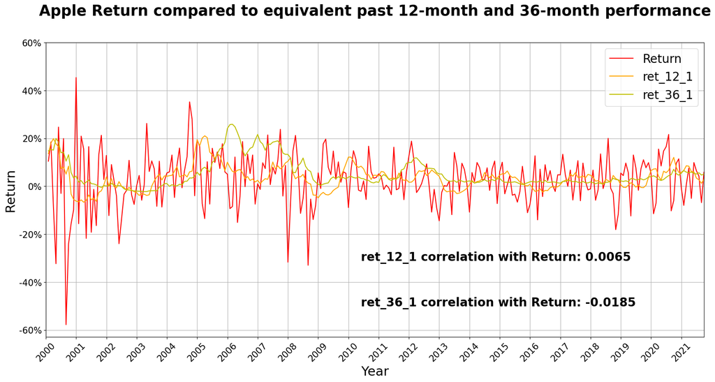

```python
my_pivot = pd.pivot_table(ti,
                        index = 'EOM',
                        values = ['Return','ret_12_1','ret_36_1'],
                        aggfunc = 'mean',#'mean','sum','median']
                         )
my_pivot['ret_12_1'] = my_pivot['ret_12_1']/11
my_pivot['ret_36_1'] = my_pivot['ret_36_1']/35
my_pivot.plot(figsize = (20,9),color = ['r','orange','y']);
plt.ylabel('Return', fontsize = 22)
plt.xlabel('Year', fontsize = 22)
plt.yticks([-0.6,-0.4,-0.2,0,0.2,0.4,0.6], ['-60%','-40%','-20%','0%','20%','40%','60%'], fontsize = 15)
plt.xticks(rotation = 45, fontsize = 15)
plt.xticks(['2000-01-31','2001-01-31','2002-01-31','2003-01-31','2004-01-31','2005-01-31','2006-01-31','2007-01-31','2008-01-31','2009-01-31','2010-01-31','2011-01-31','2012-01-31','2013-01-31','2014-01-31','2015-01-31','2016-01-31','2017-01-31','2018-01-31','2019-01-31','2020-01-31','2021-01-31'],['2000','2001','2002','2003','2004','2005','2006','2007','2008','2009','2010','2011','2012','2013','2014','2015','2016','2017','2018','2019','2020','2021'])
plt.grid()
plt.legend(fontsize=20)
plt.text(485,-0.5,'ret_36_1 correlation with Return: '+str(round(ti.loc[:,'Return'].corr(ti.loc[:,'ret_36_1']),4)), fontsize=20, fontweight = 'bold')
plt.text(485,-0.31,'ret_12_1 correlation with Return: '+str(round(ti.loc[:,'Return'].corr(ti.loc[:,'ret_12_1']),4)), fontsize=20, fontweight = 'bold')
plt.title('Apple Return compared to equivalent past 12-month and 36-month performance', fontsize = 25, fontweight = 'bold', y=1.08)
plt.savefig(FigProj+"Apple_MomentumStrategy.png", bbox_inches = 'tight');
plt.show();
```

From this graph, there is no clear conclusion to be had. It is hard to identify any trends or rules in the data. Therefore, the 12 and 36 month strategy may prove to be ineffective or somewhat random when predicting Apple's returns. While some data points may prove to follow the momentum strategy (2006-2010), it is hard to establish a definitive relationship between these three variables. Also, recent years have shown a smoothing of the returns that make it even less useful to use.

**January Barometer**

For the January Barometer hypothesis, the January returns have been compared to the following 11 month period to view the relationship between both returns.

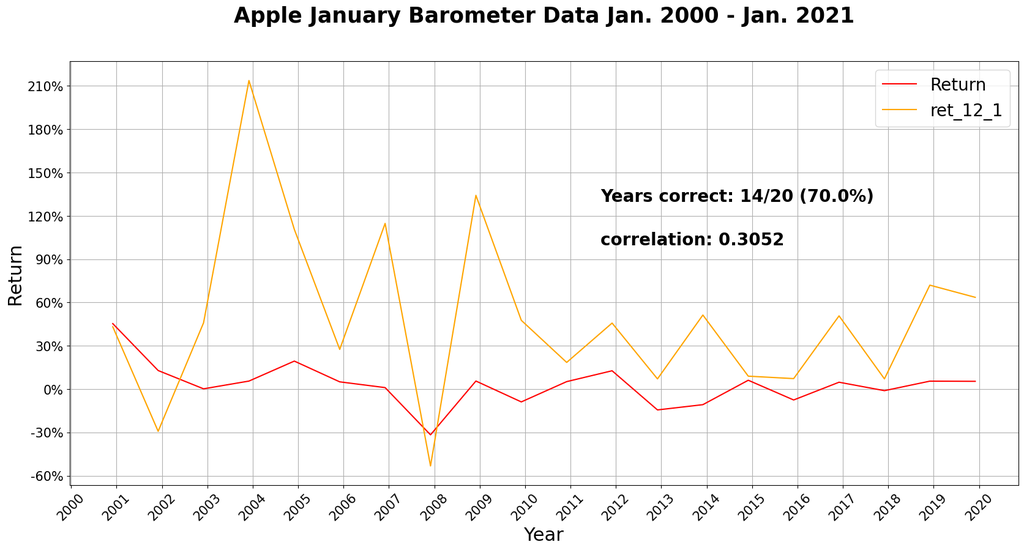

```python
january_ret = ti_up.loc[ti_up["EOM"].str.contains('Jan'), ["Return",'ret_12_1']]
january_ret['ret_12_1'] = january_ret['ret_12_1'].shift(-1)
january_ret = january_ret[:-1]

jan_cor = january_ret.corr().iloc[1,0]

cnt = len(january_ret.index)
correct_cnt = 0
for index, row in january_ret.iterrows():
    if np.sign(row[0]) == np.sign(row[1]):
        correct_cnt += 1
    else:
        continue

january_ret.plot(figsize = (20,9),color=['r','orange'])
plt.title('Apple January Barometer Data Jan. 2000 - Jan. 2021', fontsize = 25, fontweight = 'bold', y=1.08)
plt.ylabel('Return', fontsize = 22)
plt.xlabel('Year', fontsize = 22)
plt.yticks([-0.6,-0.3,0,0.3,0.6,0.9,1.2,1.5,1.8,2.1], ['-60%','-30%','0%','30%','60%','90%','120%','150%','180%','210%'], fontsize = 15)
plt.xticks(rotation = 45, fontsize = 15)
plt.xticks([0,12,24,36,48,60,72,84,96,108,120,132,144,156,168,180,192,204,216,228,240],['2000','2001','2002','2003','2004','2005','2006','2007','2008','2009','2010','2011','2012','2013','2014','2015','2016','2017','2018','2019','2020'])
plt.grid()
plt.text(140,1.3,'Years correct: '+str(round(correct_cnt,4))+'/'+str(round(cnt,4))+' ('+str(round((correct_cnt/cnt)*100,4))+'%)', fontsize=20, fontweight = 'bold')
plt.text(140,1,'correlation: '+str(round(jan_cor,4)), fontsize=20, fontweight = 'bold')
plt.legend(fontsize=20)
plt.savefig(FigProj+"Apple_JanBarometer.png", bbox_inches = 'tight');
plt.show();
```

We can see that these returns have a noticeably high correlation of 0.3052. This means that some relationship can be observed. Using the January Barometer Hypothesis, we can observe that 14/20 or roughly 70% of the years tested were in accordance with the Hypothesis. For this reason, we can conclude that the January Barometer could prove useful to paint a better picture of the year to come. However, it is relatively volatile so that the specific magnitude of the expected returns may be unknown. This should only be used to predict the sign of the future returns (positive or negative returns).

## Risk Measures

### Import the dataset of risk measures

Important ratios for further analysis:

- **EOM:** End of month
- **Return:** Monthly holding-period return.
- **PYV:** Past Year Return Volatility.
- **PMV:** Past Month Return Volatility.
- **PYMB:** Past Year Market Beta.
- **PMMB:** Past Month Market Beta.

```python
rm = pd.read_csv(Project+'Risk Measures.csv', parse_dates = ['EOM'])
rm.head()
```

|  | EOM | Return | PYV | PMV | PYMB | PMMB |
| --- | --- | --- | --- | --- | --- | --- |
| 0 | 2000-01-31 | 0.009 | 0.039 | 0.058 | 1.636 | 2.171 |
| 1 | 2000-02-29 | 0.105 | 0.039 | 0.034 | 1.589 | 1.531 |
| 2 | 2000-03-31 | 0.185 | 0.040 | 0.053 | 1.694 | 2.046 |
| 3 | 2000-04-30 | -0.087 | 0.041 | 0.050 | 1.612 | 1.165 |
| 4 | 2000-05-31 | -0.323 | 0.041 | 0.036 | 1.553 | 1.307 |

```python
rm.describe()
```

|  | Return | PYV | PMV | PYMB | PMMB |
| --- | --- | --- | --- | --- | --- |
| count | 255.000 | 263.000 | 263.000 | 263.000 | 263.000 |
| mean | 0.027 | 0.024 | 0.022 | 1.183 | 1.212 |
| std | 0.116 | 0.010 | 0.013 | 0.321 | 0.606 |
| min | -0.577 | 0.011 | 0.005 | 0.406 | -0.427 |
| 25% | -0.035 | 0.017 | 0.014 | 0.968 | 0.815 |
| 50% | 0.033 | 0.021 | 0.019 | 1.137 | 1.150 |
| 75% | 0.098 | 0.027 | 0.027 | 1.451 | 1.523 |
| max | 0.454 | 0.055 | 0.125 | 1.977 | 4.301 |

```python
rm.corr()
```

|  | Return | PYV | PMV | PYMB | PMMB |
| --- | --- | --- | --- | --- | --- |
| Return | 1.000 | -0.100 | -0.318 | -0.084 | -0.213 |
| PYV | -0.100 | 1.000 | 0.694 | 0.575 | 0.349 |
| PMV | -0.318 | 0.694 | 1.000 | 0.477 | 0.449 |
| PYMB | -0.084 | 0.575 | 0.477 | 1.000 | 0.533 |
| PMMB | -0.213 | 0.349 | 0.449 | 0.533 | 1.000 |

We have chosen to focus our attention on the predictive power of the past-month return volatility for Apple’s returns. This is due to the fact that the past-month return volatility yielded the strongest correlation coefficient between Apple’s returns and a particular risk measure at -0.3181. Despite the fact that this correlation coefficient is negative (meaning that one must perform the opposite action of what is suggested by the movement of the past-month return volatility), it has the largest absolute value across the 4 different risk measures that we have historical access to, indicating that the past-month return volatility is the most superior risk measure indicator of Apple’s future stock price movements, and it is thus of interest to follow the trends of this risk measure. Below is an analysis of the trends of the past-month return volatility of Apple’s stock from January 2000 to March 2021.

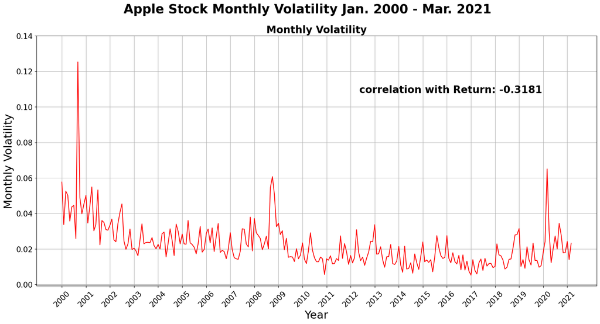

```python
fig, ax = plt.subplots(1, 1, figsize = (20,9))
fig.suptitle('Apple Stock Monthly Volatility Jan. 2000 - Mar. 2021', fontsize = 25, fontweight = 'bold')

plt.title('Monthly Volatility', fontsize = 20, fontweight = 'bold')
plt.plot(rm['EOM'],rm['PMV'],'r')
plt.ylabel('Monthly Volatility', fontsize = 22)
plt.xlabel('Year', fontsize = 22)
plt.yticks([0,0.02,0.04,0.06,0.08,0.10,0.12,0.14], fontsize = 15)
plt.xticks(rotation = 45, fontsize = 15)
plt.xticks(['2000-01-31','2001-01-31','2002-01-31','2003-01-31','2004-01-31','2005-01-31','2006-01-31','2007-01-31','2008-01-31','2009-01-31','2010-01-31','2011-01-31','2012-01-31','2013-01-31','2014-01-31','2015-01-31','2016-01-31','2017-01-31','2018-01-31','2019-01-31','2020-01-31','2021-01-31'],['2000','2001','2002','2003','2004','2005','2006','2007','2008','2009','2010','2011','2012','2013','2014','2015','2016','2017','2018','2019','2020','2021'])
plt.text(15500,0.108,'correlation with Return: '+str(round(rm.loc[:,'Return'].corr(rm.loc[:,'PMV']),4)), fontsize=20, fontweight = 'bold')
plt.grid()

plt.show();

fig.savefig(FigProj+"Apple_MonthlyVolatility.png", bbox_inches = 'tight');
```

From the time series plots above, we can observe that when the past-month return volatility is high for Apple’s stock, it tends to have lower expected returns than when the past-month return volatility is low. For instance, the large upward movement in the past-month return volatility between January 2000 and January 2001 to approximately 13% corresponds with the large downward movement in the returns of Apple between January 2000 and January 2001 to approximately –60%, while the low past-month return volatility around January 2011 that was approximately 1% corresponds with the return on Apple’s stock at the same point in time at approximately 4%. This trend largely continues throughout the graphs, and is thus consistent with what we stated above in why we believe the past-month return volatility is of significance to track.

## Investors

```python
inv = pd.read_csv(Project+'Investors.csv', parse_dates = ['EOM'])
inv = inv.drop('13F Report Period', axis=1)
inv.head()
```

|  | EOM | Return | Number of 13F Investors | Ownership of All Institutions | Ownership fof Bank | Ownership fof Insuance Company | Ownership of Mutual Fund | Ownership of Investment Advisor | Ownership of Pension Fund | Ownership of Hedge Fund | Ownership of Venture Capital | Lowest Price Target | Median Price Target | Highest Price Target | Percentage Of Analysts Recommending Sell | Percentage Of Analysts Recommending Hold | Percentage Of Analysts Recommending Buy | Net Analyst Recommendation | Insider Ownership | Short Interest | Retail Order Imbalance | Number Of Robinhood Accounts |
| --- | --- | --- | --- | --- | --- | --- | --- | --- | --- | --- | --- | --- | --- | --- | --- | --- | --- | --- | --- | --- | --- | --- |
| 0 | 2000-01-31 | 0.91% | 378 | 68.02% | 0.01% | 0.13% | 22.55% | 34.64% | 6.86% | 1.31% | 2.52% | 0.982 | 1.205 | 1.339 | 0.00% | 20.83% | 79.17% | 79.17% | 4.82% | NaN | NaN | NaN |
| 1 | 2000-02-29 | 10.48% | 378 | 68.02% | 0.01% | 0.13% | 22.55% | 34.64% | 6.86% | 1.31% | 2.52% | 0.982 | 1.223 | 1.339 | 0.00% | 20.00% | 80.00% | 80.00% | 4.82% | NaN | NaN | NaN |
| 2 | 2000-03-31 | 18.48% | 378 | 68.02% | 0.01% | 0.13% | 22.55% | 34.64% | 6.86% | 1.31% | 2.52% | 1.027 | 1.241 | 1.339 | 0.00% | 20.00% | 80.00% | 80.00% | 4.82% | NaN | NaN | NaN |
| 3 | 2000-04-30 | -8.65% | 423 | 69.72% | 0.02% | 0.13% | 20.65% | 38.77% | 6.60% | 1.02% | 2.53% | 1.027 | 1.250 | 1.562 | 0.00% | 21.74% | 78.26% | 78.26% | 4.82% | NaN | NaN | NaN |
| 4 | 2000-05-31 | -32.29% | 423 | 69.72% | 0.02% | 0.13% | 20.65% | 38.77% | 6.60% | 1.02% | 2.53% | 1.027 | 1.250 | 1.562 | 0.00% | 21.74% | 78.26% | 78.26% | 4.82% | NaN | NaN | NaN |

```python
# Clean database and turn strings to float
def p2f(x):
    return float(x.strip('%'))/100

for i in inv:
    if i == 'EOM':
        continue
    else:
        for index, row in inv.iterrows():
            if isinstance(row[i], int):
                continue
            if isinstance(row[i], float):
                continue
            elif '%' in row[i]:
                inv.loc[index,i] = p2f(row[i])
            else:
                continue
        inv.loc[:,i] = np.array(inv.loc[:,i],dtype=float)

inv.describe()
```

|  | Return | Number of 13F Investors | Ownership of All Institutions | Ownership fof Bank | Ownership fof Insuance Company | Ownership of Mutual Fund | Ownership of Investment Advisor | Ownership of Pension Fund | Ownership of Hedge Fund | Ownership of Venture Capital | Lowest Price Target | Median Price Target | Highest Price Target | Percentage Of Analysts Recommending Sell | Percentage Of Analysts Recommending Hold | Percentage Of Analysts Recommending Buy | Net Analyst Recommendation | Insider Ownership | Short Interest | Retail Order Imbalance | Number Of Robinhood Accounts |
| --- | --- | --- | --- | --- | --- | --- | --- | --- | --- | --- | --- | --- | --- | --- | --- | --- | --- | --- | --- | --- | --- |
| count | 255.000 | 255.000 | 255.000 | 255.000 | 255.000 | 255.000 | 255.000 | 255.000 | 255.000 | 255.000 | 255.000 | 255.000 | 255.000 | 255.000 | 255.000 | 255.000 | 255.000 | 255.000 | 213.000 | 135.000 | 28.000 |
| mean | 0.027 | 2,088.859 | 0.669 | 0.003 | 0.002 | 0.189 | 0.372 | 0.044 | 0.028 | 0.031 | 13.402 | 22.598 | 28.499 | 0.027 | 0.294 | 0.678 | 0.651 | 0.056 | 0.019 | 48,037.511 | 255,046.964 |
| std | 0.116 | 1,263.554 | 0.070 | 0.002 | 0.001 | 0.034 | 0.043 | 0.006 | 0.015 | 0.014 | 16.910 | 28.908 | 34.360 | 0.030 | 0.211 | 0.216 | 0.225 | 0.004 | 0.011 | 134,050.835 | 119,953.427 |
| min | -0.577 | 378.000 | 0.477 | 0.000 | 0.001 | 0.071 | 0.265 | 0.032 | 0.006 | 0.012 | 0.268 | 0.304 | 0.393 | 0.000 | 0.039 | 0.000 | -0.133 | 0.048 | 0.005 | -48,093.000 | 142,247.000 |
| 25% | -0.035 | 845.000 | 0.611 | 0.001 | 0.002 | 0.164 | 0.342 | 0.041 | 0.012 | 0.021 | 1.027 | 1.795 | 2.143 | 0.000 | 0.163 | 0.589 | 0.553 | 0.056 | 0.010 | 538.000 | 202,932.000 |
| 50% | 0.033 | 2,110.000 | 0.680 | 0.003 | 0.002 | 0.187 | 0.359 | 0.043 | 0.026 | 0.028 | 5.893 | 12.143 | 14.286 | 0.020 | 0.222 | 0.750 | 0.717 | 0.056 | 0.016 | 5,519.000 | 224,119.000 |
| 75% | 0.098 | 3,241.000 | 0.723 | 0.004 | 0.003 | 0.211 | 0.407 | 0.046 | 0.040 | 0.033 | 21.250 | 32.925 | 46.250 | 0.049 | 0.385 | 0.826 | 0.807 | 0.056 | 0.025 | 46,673.500 | 238,793.500 |
| max | 0.454 | 4,695.000 | 0.804 | 0.008 | 0.003 | 0.265 | 0.484 | 0.069 | 0.068 | 0.085 | 83.000 | 157.000 | 175.000 | 0.133 | 0.941 | 0.929 | 0.917 | 0.063 | 0.075 | 1,039,784.000 | 674,745.000 |

```python
inv.corr()
```

|  | Return | Number of 13F Investors | Ownership of All Institutions | Ownership fof Bank | Ownership fof Insuance Company | Ownership of Mutual Fund | Ownership of Investment Advisor | Ownership of Pension Fund | Ownership of Hedge Fund | Ownership of Venture Capital | Lowest Price Target | Median Price Target | Highest Price Target | Percentage Of Analysts Recommending Sell | Percentage Of Analysts Recommending Hold | Percentage Of Analysts Recommending Buy | Net Analyst Recommendation | Insider Ownership | Short Interest | Retail Order Imbalance | Number Of Robinhood Accounts |
| --- | --- | --- | --- | --- | --- | --- | --- | --- | --- | --- | --- | --- | --- | --- | --- | --- | --- | --- | --- | --- | --- |
| Return | 1.000 | -0.003 | 0.108 | 0.013 | 0.017 | 0.044 | 0.075 | -0.153 | 0.126 | 0.131 | -0.011 | -0.013 | -0.020 | 0.086 | -0.007 | -0.005 | -0.017 | 0.191 | 0.128 | -0.121 | 0.430 |
| Number of 13F Investors | -0.003 | 1.000 | -0.465 | 0.617 | 0.714 | -0.492 | -0.099 | -0.631 | -0.410 | -0.219 | 0.866 | 0.848 | 0.877 | 0.155 | -0.493 | 0.461 | 0.422 | 0.109 | -0.823 | 0.457 | 0.805 |
| Ownership of All Institutions | 0.108 | -0.465 | 1.000 | -0.294 | -0.333 | 0.804 | 0.771 | 0.073 | 0.697 | -0.031 | -0.530 | -0.489 | -0.513 | 0.080 | -0.151 | 0.137 | 0.121 | 0.497 | 0.649 | -0.237 | 0.355 |
| Ownership fof Bank | 0.013 | 0.617 | -0.294 | 1.000 | 0.541 | -0.276 | -0.104 | -0.544 | -0.208 | -0.167 | 0.526 | 0.489 | 0.493 | -0.023 | -0.288 | 0.285 | 0.277 | 0.085 | -0.429 | 0.252 | 0.598 |
| Ownership fof Insuance Company | 0.017 | 0.714 | -0.333 | 0.541 | 1.000 | -0.491 | 0.018 | -0.352 | -0.083 | -0.400 | 0.407 | 0.363 | 0.408 | -0.171 | -0.634 | 0.643 | 0.641 | 0.034 | -0.524 | -0.240 | -0.495 |
| Ownership of Mutual Fund | 0.044 | -0.492 | 0.804 | -0.276 | -0.491 | 1.000 | 0.302 | 0.162 | 0.318 | 0.326 | -0.437 | -0.411 | -0.437 | 0.209 | 0.157 | -0.182 | -0.202 | 0.357 | 0.636 | -0.134 | 0.730 |
| Ownership of Investment Advisor | 0.075 | -0.099 | 0.771 | -0.104 | 0.018 | 0.302 | 1.000 | -0.107 | 0.615 | -0.541 | -0.255 | -0.220 | -0.229 | 0.005 | -0.499 | 0.487 | 0.467 | 0.369 | 0.300 | -0.218 | -0.361 |
| Ownership of Pension Fund | -0.153 | -0.631 | 0.073 | -0.544 | -0.352 | 0.162 | -0.107 | 1.000 | -0.019 | -0.045 | -0.598 | -0.582 | -0.584 | -0.312 | 0.146 | -0.100 | -0.055 | -0.543 | 0.396 | -0.421 | -0.589 |
| Ownership of Hedge Fund | 0.126 | -0.410 | 0.697 | -0.208 | -0.083 | 0.318 | 0.615 | -0.019 | 1.000 | -0.216 | -0.568 | -0.520 | -0.532 | -0.122 | -0.254 | 0.265 | 0.270 | 0.398 | 0.585 | -0.247 | -0.297 |
| Ownership of Venture Capital | 0.131 | -0.219 | -0.031 | -0.167 | -0.400 | 0.326 | -0.541 | -0.045 | -0.216 | 1.000 | -0.013 | -0.036 | -0.047 | 0.169 | 0.663 | -0.671 | -0.667 | 0.291 | 0.313 | 0.228 | 0.169 |
| Lowest Price Target | -0.011 | 0.866 | -0.530 | 0.526 | 0.407 | -0.437 | -0.255 | -0.598 | -0.568 | -0.013 | 1.000 | 0.967 | 0.969 | 0.133 | -0.202 | 0.179 | 0.155 | 0.051 | -0.644 | 0.500 | 0.567 |
| Median Price Target | -0.013 | 0.848 | -0.489 | 0.489 | 0.363 | -0.411 | -0.220 | -0.582 | -0.520 | -0.036 | 0.967 | 1.000 | 0.994 | 0.226 | -0.244 | 0.208 | 0.170 | 0.049 | -0.638 | 0.676 | 0.831 |
| Highest Price Target | -0.020 | 0.877 | -0.513 | 0.493 | 0.408 | -0.437 | -0.229 | -0.584 | -0.532 | -0.047 | 0.969 | 0.994 | 1.000 | 0.220 | -0.263 | 0.226 | 0.189 | 0.050 | -0.659 | 0.669 | 0.853 |
| Percentage Of Analysts Recommending Sell | 0.086 | 0.155 | 0.080 | -0.023 | -0.171 | 0.209 | 0.005 | -0.312 | -0.122 | 0.169 | 0.133 | 0.226 | 0.220 | 1.000 | 0.098 | -0.233 | -0.356 | 0.237 | -0.071 | 0.315 | 0.437 |
| Percentage Of Analysts Recommending Hold | -0.007 | -0.493 | -0.151 | -0.288 | -0.634 | 0.157 | -0.499 | 0.146 | -0.254 | 0.663 | -0.202 | -0.244 | -0.263 | 0.098 | 1.000 | -0.991 | -0.965 | -0.047 | 0.440 | 0.056 | -0.562 |
| Percentage Of Analysts Recommending Buy | -0.005 | 0.461 | 0.137 | 0.285 | 0.643 | -0.182 | 0.487 | -0.100 | 0.265 | -0.671 | 0.179 | 0.208 | 0.226 | -0.233 | -0.991 | 1.000 | 0.992 | 0.013 | -0.422 | -0.123 | 0.435 |
| Net Analyst Recommendation | -0.017 | 0.422 | 0.121 | 0.277 | 0.641 | -0.202 | 0.467 | -0.055 | 0.270 | -0.667 | 0.155 | 0.170 | 0.189 | -0.356 | -0.965 | 0.992 | 1.000 | -0.019 | -0.395 | -0.179 | 0.246 |
| Insider Ownership | 0.191 | 0.109 | 0.497 | 0.085 | 0.034 | 0.357 | 0.369 | -0.543 | 0.398 | 0.291 | 0.051 | 0.049 | 0.050 | 0.237 | -0.047 | 0.013 | -0.019 | 1.000 | 0.680 | 0.250 | 0.448 |
| Short Interest | 0.128 | -0.823 | 0.649 | -0.429 | -0.524 | 0.636 | 0.300 | 0.396 | 0.585 | 0.313 | -0.644 | -0.638 | -0.659 | -0.071 | 0.440 | -0.422 | -0.395 | 0.680 | 1.000 | -0.283 | -0.382 |
| Retail Order Imbalance | -0.121 | 0.457 | -0.237 | 0.252 | -0.240 | -0.134 | -0.218 | -0.421 | -0.247 | 0.228 | 0.500 | 0.676 | 0.669 | 0.315 | 0.056 | -0.123 | -0.179 | 0.250 | -0.283 | 1.000 | 0.799 |
| Number Of Robinhood Accounts | 0.430 | 0.805 | 0.355 | 0.598 | -0.495 | 0.730 | -0.361 | -0.589 | -0.297 | 0.169 | 0.567 | 0.831 | 0.853 | 0.437 | -0.562 | 0.435 | 0.246 | 0.448 | -0.382 | 0.799 | 1.000 |

We have chosen to focus our attention on the predictive power of venture capital for Apple’s returns. This is because amongst all 13F institutions, investment advisors, mutual funds, hedge funds, and venture capital, venture capital yields the highest positive correlation coefficient between Apple’s returns and institutional ownership of 0.1313. This indicates that amongst these five particular types of institutional investors, venture capital has the most superior information about future stock price movements of Apple and it is thus of interest to follow their institutional ownership trends. Below is an analysis of the trends of the ownership of Apple held by venture capital from January 2000 to March 2021.

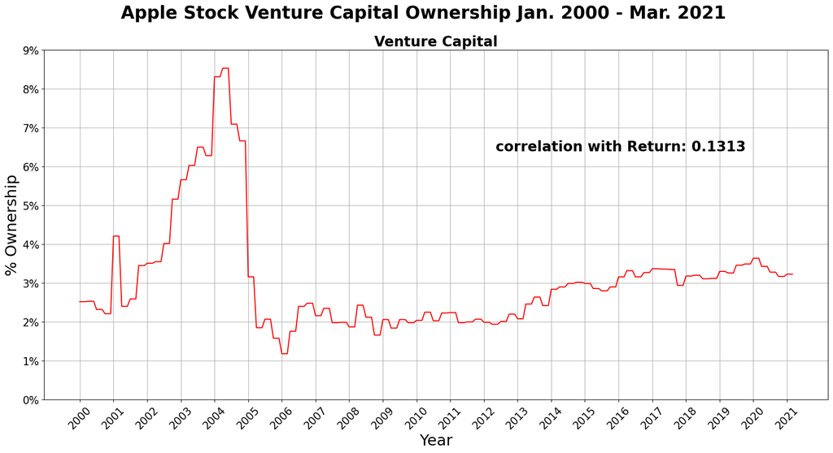

```python
fig, ax = plt.subplots(1, 1, figsize = (20,9))
fig.suptitle('Apple Stock Venture Capital Ownership Jan. 2000 - Mar. 2021', fontsize = 25, fontweight = 'bold')

plt.title('Venture Capital', fontsize = 20, fontweight = 'bold')
plt.plot(inv['EOM'],inv['Ownership of Venture Capital'],'r')
plt.ylabel('% Ownership', fontsize = 22)
plt.xlabel('Year', fontsize = 22)
plt.yticks([0,0.01,0.02,0.03,0.04,0.05,0.06,0.07,0.08,0.09], ['0%','1%','2%','3%','4%','5%','6%','7%','8%','9%'], fontsize = 15)
plt.xticks(rotation = 45, fontsize = 15)
plt.xticks(['2000-01-31','2001-01-31','2002-01-31','2003-01-31','2004-01-31','2005-01-31','2006-01-31','2007-01-31','2008-01-31','2009-01-31','2010-01-31','2011-01-31','2012-01-31','2013-01-31','2014-01-31','2015-01-31','2016-01-31','2017-01-31','2018-01-31','2019-01-31','2020-01-31','2021-01-31'],['2000','2001','2002','2003','2004','2005','2006','2007','2008','2009','2010','2011','2012','2013','2014','2015','2016','2017','2018','2019','2020','2021'])
plt.text(15500,0.064,'correlation with Return: '+str(round(inv.loc[:,'Return'].corr(inv.loc[:,'Ownership of Venture Capital']),4)), fontsize=20, fontweight = 'bold')
plt.grid()

plt.show();

fig.savefig(FigProj+"Apple_VentureCapital.png", bbox_inches = 'tight');
```

By observing our time series plot of the sample average of ownership held by venture capital from January 2000 to March 2021 (reported quarterly), we see that the sample ownership has been mostly stable over time. It is noteworthy that in late 2000 the sample ownership held by venture capital rose sharply from a little above 2% to over 4%, then fell sharply back to around 2% in early 2001. We believe that this most likely corresponds to the tech bubble burst.

Another unstable period of time was when the sample ownership held by venture capital rose sharply from about 6% in mid-2003 to about 8.5% by March 2004, then fell sharply over the next year to a low of about 1% in late 2005. While we do not know of any major economic events happening during this time period, Apple itself had significant product innovations in the way of integrating iTunes with the iPod and releasing the iPod Mini in 2004, which may have led to the decline in sample ownership held by venture capital due to the massively successful, ahead-of-its-time nature of these product innovations.

After late 2005, there was less overall fluctuation in the sample ownership held by venture capital, hovering between approximately 1.5% and 3.5% with a predominantly upward trend to be observed. This demonstrates to us that the 2008 housing crisis and the COVID-19 pandemic of 2020 had little to no effect on venture capital’s approach to ownership of Apple’s stock, and we believe that this makes sense because of Apple’s ever-growing presence in the global economy as a technological powerhouse; as Apple matures as a company, it has less incentive to engage with venture capital due to both its growing ability to generate enough cash flows on its own to cover its debts and less need for consultation and guidance regarding their business matters.

In contrast, we can see from the time series plot of Apple’s returns during the same time period that Apple’s returns were sharply affected by all three of these events. Although the correlation coefficient of 0.1313 between Apple’s returns and venture capital’s institutional ownership is the largest positive correlation coefficient to be observed between the five categories of institutional investors we considered in our analysis, this is still a moderately weak correlation between the two items which explains why the movements of venture capital’s institutional ownership do not strongly mimic those of Apple’s returns. Thus, although it can be mildly informative in determining when to buy and sell Apple stock, we would recommend not placing too much weight on the predictive power of venture capital for Apple’s returns when making investing decisions.

## 400 Trading Signals

### Import the dataset of trading signals

The definition and categorization of each signal can be found [here.](https://drive.google.com/file/d/12g2-q5zEFmA70acqZDoTFSmzdDx4js_v/view?usp=sharing)

*Data received as part of the Final Project in the MGMT411 class at Purdue University with Dr. Shuaiyu Chen.*

```python
trade = pd.read_csv(Project +'400 Trading Signals.csv', parse_dates = ['EOM'])
trade_bu = pd.read_csv(Project +'400 Trading Signals.csv', parse_dates = ['EOM'])
trade.head(10)
```

|  | EOM | Return | dolvol | market_equity | enterprise_value | book_equity | assets | sales | net_income | bidask | div1m_me | div3m_me | div6m_me | div12m_me | divspc1m_me | divspc12m_me | chcsho_1m | chcsho_3m | chcsho_6m | chcsho_12m | eqnpo_1m | eqnpo_3m | eqnpo_6m | eqnpo_12m | ret_1_0 | ret_2_0 | ret_3_0 | ret_3_1 | ret_6_0 | … |
| --- | --- | --- | --- | --- | --- | --- | --- | --- | --- | --- | --- | --- | --- | --- | --- | --- | --- | --- | --- | --- | --- | --- | --- | --- | --- | --- | --- | --- | --- | --- |
| 0 | 2000-02-29 | 0.105 | 3,802,988,131.000 | 18,472.850 | 15,546.850 | 3162 | 5161 | 6134 | 601 | 0 | 0.000 | 0.000 | 0.000 | 0.000 | NaN | NaN | 0.000 | 0.000 | 0.181 | 0.181 | -0.000 | -0.000 | -0.167 | -0.167 | 0.009 | 0.060 | 0.295 | 0.283 | 0.863 | … |
| 1 | 2000-03-31 | 0.185 | 5,354,136,188.000 | 22,093.978 | 19,167.978 | 3162 | 5161 | 6134 | 601 | 0 | 0.000 | 0.000 | 0.000 | 0.000 | NaN | NaN | 0.009 | 0.009 | 0.009 | 0.193 | -0.009 | -0.009 | -0.009 | -0.176 | 0.105 | 0.115 | 0.171 | 0.060 | 0.757 | … |
| 2 | 2000-04-30 | -0.087 | 4,859,186,953.000 | 20,182.487 | 16,822.487 | 5171 | 7586 | 6767 | 632 | 0 | 0.000 | 0.000 | 0.000 | 0.000 | NaN | NaN | 0.000 | 0.009 | 0.009 | 0.193 | 0.000 | -0.009 | -0.009 | -0.176 | 0.185 | 0.309 | 0.321 | 0.115 | 1.145 | … |
| 3 | 2000-05-31 | -0.323 | 3,724,077,000.000 | 13,670.496 | 10,310.496 | 5171 | 7586 | 6767 | 632 | 0 | 0.000 | 0.000 | 0.000 | 0.000 | NaN | NaN | 0.000 | 0.010 | 0.010 | 0.193 | -0.000 | -0.010 | -0.010 | -0.176 | -0.087 | 0.082 | 0.196 | 0.309 | 0.548 | … |
| 4 | 2000-06-30 | 0.247 | 2,481,087,550.000 | 17,012.762 | 13,652.762 | 5171 | 7586 | 6767 | 632 | 0 | 0.000 | 0.000 | 0.000 | 0.000 | NaN | NaN | -0.002 | -0.002 | 0.008 | 0.191 | 0.002 | 0.002 | -0.008 | -0.174 | -0.323 | -0.382 | -0.267 | 0.082 | -0.142 | … |
| 5 | 2000-07-31 | -0.030 | 2,648,286,525.000 | 16,512.487 | 13,203.487 | 4704 | 7007 | 7182 | 730 | 0 | 0.000 | 0.000 | 0.000 | 0.000 | NaN | NaN | 0.000 | -0.001 | 0.008 | 0.191 | -0.000 | 0.001 | -0.008 | -0.175 | 0.247 | -0.156 | -0.229 | -0.382 | 0.019 | … |
| 6 | 2000-08-31 | 0.199 | 3,101,819,297.000 | 19,802.798 | 16,493.798 | 4704 | 7007 | 7182 | 730 | 0 | 0.000 | 0.000 | 0.000 | 0.000 | NaN | NaN | 0.000 | -0.002 | 0.008 | 0.191 | 0.000 | 0.002 | -0.008 | -0.175 | -0.030 | 0.210 | -0.181 | -0.156 | -0.020 | … |
| 7 | 2000-09-30 | -0.577 | 3,383,783,038.000 | 8,643.683 | 5,334.683 | 4704 | 7007 | 7182 | 730 | 0 | 0.000 | 0.000 | 0.000 | 0.000 | NaN | NaN | 0.033 | 0.033 | 0.032 | 0.041 | -0.032 | -0.033 | -0.031 | -0.041 | 0.199 | 0.163 | 0.451 | 0.210 | 0.063 | … |
| 8 | 2000-10-31 | -0.240 | 3,866,495,847.000 | 6,568.422 | 3,042.422 | 4609 | 6932 | 7449 | 727 | 0 | 0.000 | 0.000 | 0.000 | 0.000 | NaN | NaN | 0.000 | 0.033 | 0.032 | 0.042 | -0.000 | -0.033 | -0.031 | -0.041 | -0.577 | -0.493 | -0.508 | 0.163 | -0.621 | … |
| 9 | 2000-11-30 | -0.157 | 1,269,354,075.000 | 5,540.139 | 2,014.139 | 4609 | 6932 | 7449 | 727 | 0 | 0.000 | 0.000 | 0.000 | 0.000 | NaN | NaN | 0.000 | 0.033 | 0.032 | 0.042 | 0.000 | -0.033 | -0.031 | -0.041 | -0.240 | -0.679 | -0.615 | -0.493 | -0.685 | … |

```python
trade.describe()
```

|  | Return | dolvol | market_equity | enterprise_value | book_equity | assets | sales | net_income | bidask | div1m_me | div3m_me | div6m_me | div12m_me | divspc1m_me | divspc12m_me | chcsho_1m | chcsho_3m | chcsho_6m | chcsho_12m | eqnpo_1m | eqnpo_3m | eqnpo_6m | eqnpo_12m | ret_1_0 | ret_2_0 | ret_3_0 | ret_3_1 | ret_6_0 | ret_6_1 | … |
| --- | --- | --- | --- | --- | --- | --- | --- | --- | --- | --- | --- | --- | --- | --- | --- | --- | --- | --- | --- | --- | --- | --- | --- | --- | --- | --- | --- | --- | --- | --- |
| count | 261.000 | 261.000 | 261.000 | 261.000 | 261.000 | 261.000 | 261.000 | 261.000 | 261.000 | 261.000 | 261.000 | 261.000 | 261.000 | 0.000 | 0.000 | 261.000 | 261.000 | 261.000 | 261.000 | 261.000 | 261.000 | 261.000 | 261.000 | 261.000 | 261.000 | 261.000 | 261.000 | 261.000 | 261.000 | … |
| mean | 0.027 | 100,192,676,601.057 | 464,315.992 | 462,634.153 | 65,488.398 | 141,053.498 | 111,358.226 | 24,071.525 | 0.000 | 0.001 | 0.002 | 0.003 | 0.007 | NaN | NaN | -0.000 | -0.001 | -0.001 | 0.002 | 0.001 | 0.003 | 0.005 | 0.006 | 0.027 | 0.056 | 0.087 | 0.057 | 0.189 | 0.156 | … |
| std | 0.115 | 84,981,289,779.714 | 557,489.429 | 572,079.692 | 59,367.079 | 139,341.929 | 104,463.415 | 23,815.113 | 0.000 | 0.002 | 0.002 | 0.004 | 0.008 | NaN | NaN | 0.007 | 0.013 | 0.026 | 0.055 | 0.007 | 0.015 | 0.029 | 0.060 | 0.115 | 0.169 | 0.217 | 0.169 | 0.347 | 0.307 | … |
| min | -0.577 | 643,443,366.900 | 5,136.442 | 1,056.050 | 3,162.000 | 5,161.000 | 5,363.000 | -37.000 | 0.000 | 0.000 | 0.000 | 0.000 | 0.000 | NaN | NaN | -0.034 | -0.039 | -0.058 | -0.083 | -0.032 | -0.043 | -0.167 | -0.176 | -0.577 | -0.679 | -0.729 | -0.679 | -0.716 | -0.707 | … |
| 25% | -0.035 | 23,783,610,364.000 | 36,658.336 | 31,194.336 | 6,518.000 | 10,111.000 | 11,097.000 | 786.000 | 0.000 | 0.000 | 0.000 | 0.000 | 0.000 | NaN | NaN | 0.000 | -0.009 | -0.021 | -0.047 | -0.002 | -0.005 | -0.010 | -0.022 | -0.035 | -0.036 | -0.026 | -0.036 | 0.006 | -0.011 | … |
| 50% | 0.037 | 96,337,313,887.000 | 297,089.047 | 272,801.047 | 46,939.000 | 64,725.000 | 57,089.000 | 12,237.000 | 0.000 | 0.000 | 0.000 | 0.000 | 0.000 | NaN | NaN | 0.000 | 0.002 | 0.006 | 0.013 | 0.000 | -0.002 | -0.005 | -0.013 | 0.034 | 0.060 | 0.089 | 0.060 | 0.174 | 0.139 | … |
| 75% | 0.098 | 146,000,000,000.000 | 666,252.054 | 685,967.054 | 131,806.000 | 293,284.000 | 219,740.000 | 46,651.000 | 0.000 | 0.000 | 0.004 | 0.008 | 0.015 | NaN | NaN | 0.002 | 0.005 | 0.010 | 0.023 | 0.003 | 0.012 | 0.029 | 0.066 | 0.098 | 0.161 | 0.203 | 0.163 | 0.352 | 0.310 | … |
| max | 0.454 | 450,000,000,000.000 | 2,509,775.134 | 2,561,586.134 | 165,551.000 | 406,794.000 | 347,155.000 | 86,802.000 | 0.000 | 0.007 | 0.008 | 0.015 | 0.029 | NaN | NaN | 0.033 | 0.044 | 0.181 | 0.193 | 0.034 | 0.044 | 0.067 | 0.111 | 0.454 | 0.730 | 0.944 | 0.730 | 1.601 | 1.315 | … |

For this analysis, we will be using three functions to divide all signal values into two performance bins: "Buy" bin and "Sell" bin, according to the historic median value for each signal. After this, we will calculate the average retrn for each signal bin and, using a difference between the two, we can figure out how much can be earned by trading with each signal. In order to focus on the best signals, the top 10 and the bottom 10 signals out of the 400 available will be selected and analyzed.

**Function 1: Dividing signal by bins**

```python
# Divide signals according to signal value into two bins (percentile-based)
def DualPortfolios(signalset, signal): #Signal set is database, signal is variable to analyze
    signalset_ = signalset[['EOM',signal]].dropna().reset_index(drop = True)
    breakpoint = signalset_[signal].describe(percentiles=[.5]).iloc[4]
    sig_df = []
    for index,row in signalset_.iterrows():
        if signalset_.iloc[index,1] < breakpoint:
            sig_df.append(signal+'_1')
        elif row[signal] >= breakpoint:
            sig_df.append(signal+'_2')
        else:
            sig_df.append(signal+'_NaN')
    signalset_[signal+'_PTF'] = sig_df
    return signalset_
```

**Function 2: Applying function 1 to all signals**

```python
# Assign bins for all trading signals
def SignalDivision(signalset):
    new_df = signalset
    for col in signalset:
        if col == 'EOM' or col == 'Return':
            continue
        df = DualPortfolios(signalset,col)
        new_df[col] = df.iloc[:,2]
    new_df = new_df.dropna(axis=1, how='all')
    return new_df
```

**Function 3: Calculating the average return for each bin and the final tradeable difference**

```python
def AverageReturn(signal,signaldiv):
    signaldiv = signaldiv[['EOM','Return',signal]].dropna().reset_index(drop = True)
    d1 = 0
    w1 = 0
    d2 = 0
    w2 = 0
    for index, row in signaldiv.iterrows():
        if row.iloc[2] == signal+'_1':
            d1 += row.iloc[1]
            w1 += 1
        if row.iloc[2] == signal+'_2':
            d2 += row.iloc[1]
            w2 += 1
    if w1 == 0 or w2 == 0:
        dif=0
    else:
        wav1 = d1/w1
        wav2 = d2/w2
        dif = wav2-wav1
    return dif
```

**Visualize function results**

```python
signal_div = SignalDivision(trade)
signal_div.head()
```

|  | EOM | Return | dolvol | market_equity | enterprise_value | book_equity | assets | sales | net_income | bidask | div1m_me | div3m_me | div6m_me | div12m_me | chcsho_1m | chcsho_3m | chcsho_6m | chcsho_12m | eqnpo_1m | eqnpo_3m | eqnpo_6m | eqnpo_12m | ret_1_0 | ret_2_0 | ret_3_0 | ret_3_1 | ret_6_0 | ret_6_1 | ret_9_0 | … |
| --- | --- | --- | --- | --- | --- | --- | --- | --- | --- | --- | --- | --- | --- | --- | --- | --- | --- | --- | --- | --- | --- | --- | --- | --- | --- | --- | --- | --- | --- | --- |
| 0 | 2000-02-29 | 0.105 | dolvol_1 | market_equity_1 | enterprise_value_1 | book_equity_1 | assets_1 | sales_1 | net_income_1 | bidask_2 | div1m_me_2 | div3m_me_2 | div6m_me_2 | div12m_me_2 | chcsho_1m_2 | chcsho_3m_1 | chcsho_6m_2 | chcsho_12m_2 | eqnpo_1m_1 | eqnpo_3m_2 | eqnpo_6m_1 | eqnpo_12m_1 | ret_1_0_1 | ret_2_0_2 | ret_3_0_2 | ret_3_1_2 | ret_6_0_2 | ret_6_1_2 | ret_9_0_2 | … |
| 1 | 2000-03-31 | 0.185 | dolvol_1 | market_equity_1 | enterprise_value_1 | book_equity_1 | assets_1 | sales_1 | net_income_1 | bidask_2 | div1m_me_2 | div3m_me_2 | div6m_me_2 | div12m_me_2 | chcsho_1m_2 | chcsho_3m_2 | chcsho_6m_2 | chcsho_12m_2 | eqnpo_1m_1 | eqnpo_3m_1 | eqnpo_6m_1 | eqnpo_12m_1 | ret_1_0_2 | ret_2_0_2 | ret_3_0_2 | ret_3_1_2 | ret_6_0_2 | ret_6_1_2 | ret_9_0_2 | … |
| 2 | 2000-04-30 | -0.087 | dolvol_1 | market_equity_1 | enterprise_value_1 | book_equity_1 | assets_1 | sales_1 | net_income_1 | bidask_2 | div1m_me_2 | div3m_me_2 | div6m_me_2 | div12m_me_2 | chcsho_1m_2 | chcsho_3m_2 | chcsho_6m_2 | chcsho_12m_2 | eqnpo_1m_2 | eqnpo_3m_1 | eqnpo_6m_1 | eqnpo_12m_1 | ret_1_0_2 | ret_2_0_2 | ret_3_0_2 | ret_3_1_2 | ret_6_0_2 | ret_6_1_2 | ret_9_0_2 | … |
| 3 | 2000-05-31 | -0.323 | dolvol_1 | market_equity_1 | enterprise_value_1 | book_equity_1 | assets_1 | sales_1 | net_income_1 | bidask_2 | div1m_me_2 | div3m_me_2 | div6m_me_2 | div12m_me_2 | chcsho_1m_2 | chcsho_3m_2 | chcsho_6m_2 | chcsho_12m_2 | eqnpo_1m_1 | eqnpo_3m_1 | eqnpo_6m_1 | eqnpo_12m_1 | ret_1_0_1 | ret_2_0_2 | ret_3_0_2 | ret_3_1_2 | ret_6_0_2 | ret_6_1_2 | ret_9_0_2 | … |
| 4 | 2000-06-30 | 0.247 | dolvol_1 | market_equity_1 | enterprise_value_1 | book_equity_1 | assets_1 | sales_1 | net_income_1 | bidask_2 | div1m_me_2 | div3m_me_2 | div6m_me_2 | div12m_me_2 | chcsho_1m_1 | chcsho_3m_1 | chcsho_6m_2 | chcsho_12m_2 | eqnpo_1m_2 | eqnpo_3m_2 | eqnpo_6m_1 | eqnpo_12m_1 | ret_1_0_1 | ret_2_0_1 | ret_3_0_1 | ret_3_1_2 | ret_6_0_1 | ret_6_1_2 | ret_9_0_1 | … |

**Calculate Average return for each signal bin pair**

```python
final_signals = {}
for col in signal_div:
    if col == 'EOM' or col == 'Return':
        continue
    val = AverageReturn(col,signal_div)
    final_signals[col] = val
```

**Sort results by top 10 and bottom 10 signals**

```python
# Best 10 and worst 10 signals

# Select number of items to analyze
N = 10

# Using sorted() + itemgetter() + items()
res_top = dict(sorted(final_signals.items(), key = itemgetter(1), reverse = True)[:N]) # Top 10 signals
res_bot = dict(sorted(final_signals.items(), key = itemgetter(1))[:N])  # Bottom 10 signals

# Preparing plot
names_top = list(res_top.keys())
values_top = list(res_top.values())
names_bot = list(res_bot.keys())
values_bot = list(res_bot.values())
```

**Plot Results**

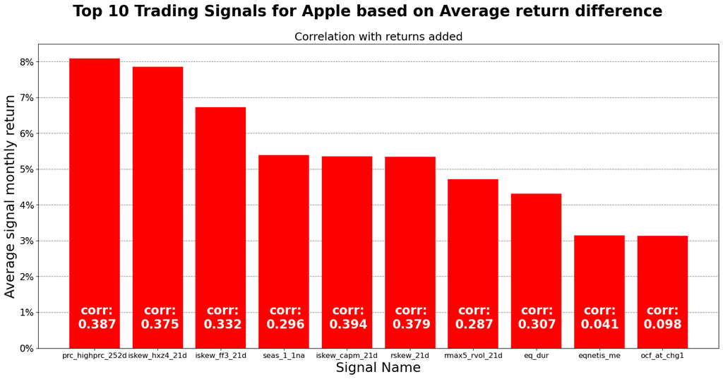

```python
fig, ax = plt.subplots(1, 1, figsize = (20,9), sharex = True, sharey = True)
fig.suptitle('Top 10 Trading Signals for Apple based on Average return difference', fontsize = 25, fontweight = 'bold')
plt.bar(range(len(res_top)), values_top, tick_label=names_top,color='r')
plt.title('Correlation with returns added', fontsize = 18)
plt.ylabel('Average signal monthly return', fontsize = 22)
plt.xlabel('Signal Name', fontsize = 22)
plt.yticks([0,0.01,0.02,0.03,0.04,0.05,0.06,0.07,0.08], ['0%','1%','2%','3%','4%','5%','6%','7%','8%'], fontsize = 15)
plt.xticks(rotation = 0, fontsize = 12)
ax.set_axisbelow(True)
ax.yaxis.grid(color='gray', linestyle='dashed')
num1 = 0.192
for i in names_top:
    plt.figtext(num1,0.16,'corr:'+'\n'+str(round(trade_bu['Return'].corr(trade_bu[i]),3)), fontsize=20, fontweight = 'bold',horizontalalignment='center',color='w')
    num1 += 0.0716
plt.show();
fig.savefig(FigProj+"Top10Signals.png", bbox_inches = 'tight');
```

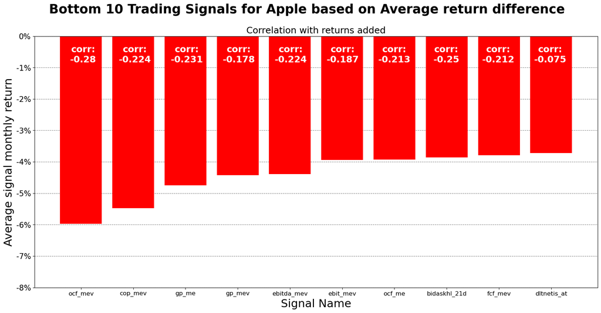

```python
fig, ax = plt.subplots(1, 1, figsize = (20,9), sharex = True, sharey = True)
fig.suptitle('Bottom 10 Trading Signals for Apple based on Average return difference', fontsize = 25, fontweight = 'bold')
plt.bar(range(len(res_bot)), values_bot, tick_label=names_bot,color='r')
plt.title('Correlation with returns added', fontsize = 18)
plt.ylabel('Average signal monthly return', fontsize = 22)
plt.xlabel('Signal Name', fontsize = 22)
plt.yticks([0,-0.01,-0.02,-0.03,-0.04,-0.05,-0.06,-0.07,-0.08], ['0%','-1%','-2%','-3%','-4%','-5%','-6%','-7%','-8%'], fontsize = 15)
plt.xticks(rotation = 0, fontsize = 12)
ax.set_axisbelow(True)
ax.yaxis.grid(color='gray', linestyle='dashed')
num1 = 0.192
for i in names_bot:
    plt.figtext(num1,0.8,'corr:'+'\n'+str(round(trade_bu['Return'].corr(trade_bu[i]),3)), fontsize=18, fontweight = 'bold',horizontalalignment='center',color='w')
    num1 += 0.0714
plt.show();
fig.savefig(FigProj+"Bottom10Signals.png", bbox_inches = 'tight');
```

From these two graphs, it is interesting to note that idiosyncratic skewness could prove to be one of the best indicators of good trading signals, with a lot of them appearing in the top 10 trading signals. These measure 'the description of the return distribution that deviates from that symmetry caused by other factors'. This is consistent with our previous analysis on technical indicators because it proves that longer-term technical analysis may not be ideal for this stock. It is also interesting to note that Current price to high price over last year is the top signal. This could also be an important trading signal that is related to the January Barometer Hypothesis. For these top 10 signals, you should buy when they are high and sell when they are low.

As for the bottom 10 signals, it is interesting to note that most signals include the Market Enterprise Value in one way or another. This value is defined as a measure of a company's total value, including the market capitalization of a company but also short-term and long-term debt and any cash or cash equivalents on the company's balance sheet. Because the "price" of a stock is in the denominator, it is only logical that these have a negative correlation with the price. These could be used to trade too, with the buy period being when the signals are low and the sell period being when they are high.